# Predict Bike Sharing Demand with AutoGluon Template

## Project: Predict Bike Sharing Demand with AutoGluon

This notebook is a template with each step that you need to complete for the project.

Please fill in your code where there are explicit `?` markers in the notebook. You are welcome to add more cells and code as you see fit.

Once you have completed all the code implementations, please export your notebook as a HTML file so the reviews can view your code. Make sure you have all outputs correctly outputted.

`File-> Export Notebook As... -> Export Notebook as HTML`

There is a writeup to complete as well after all code implememtation is done. Please answer all questions and attach the necessary tables and charts. You can complete the writeup in either markdown or PDF.

Completing the code template and writeup template will cover all of the rubric points for this project.

The rubric contains "Stand Out Suggestions" for enhancing the project beyond the minimum requirements. The stand out suggestions are optional. If you decide to pursue the "stand out suggestions", you can include the code in this notebook and also discuss the results in the writeup file.

## Step 1: Create an account with Kaggle

### Create Kaggle Account and download API key

Below is example of steps to get the API username and key. Each student will have their own username and key.

1. Open account settings.
2. Scroll down to API and click Create New API Token.
3. Open up `kaggle.json` and use the username and key.

## Step 2: Download the Kaggle dataset using the kaggle python library

### Open up Sagemaker Studio and use starter template

1. Notebook should be using a `ml.t3.medium` instance (2 vCPU + 4 GiB)
2. Notebook should be using kernal: `Python 3 (MXNet 1.8 Python 3.7 CPU Optimized)`

### Install packages

```python
# I installed all the below packages on my local machine
!pip install -U pip
!pip install -U setuptools wheel
!pip install -U "mxnet<2.0.0" bokeh==2.0.1
!pip install autogluon --no-cache-dir
# Without --no-cache-dir, smaller aws instances may have trouble installing
```

### Setup Kaggle API Key

```python
# create the .kaggle directory and an empty kaggle.json file
!mkdir -p /.kaggle
!touch /root/.kaggle/kaggle.json
!chmod 600 /root/.kaggle/kaggle.json
```

```python
!ls
```

```python
# Fill in your user name and key from creating the kaggle account and API token file
import json
kaggle_username = "redietmillionmoges"
kaggle_key = "9bcb6f7b00c944ee060921dbfc8d83b5"

# Save API token the kaggle.json file
with open("/root/.kaggle/kaggle.json", "w") as f:
    f.write(json.dumps({"username": kaggle_username, "key": kaggle_key}))
```

```python
!ls
```

```
AutogluonModels			    sampleSubmission.csv
bike-sharing-demand.zip		    submission.csv
kaggle				    submission_new_features.csv
model_test_score.png		    submission_new_hpo.csv
model_train_score.png		    test.csv
project1_Bike_sharing_demand.ipynb  train.csv
```

### Download and explore dataset

### Go to the bike sharing demand competition and agree to the terms

```python
# Download the dataset, it will be in a .zip file so you'll need to unzip it as well.
!kaggle competitions download -c bike-sharing-demand
# If you already downloaded it you can use the -o command to overwrite the file
!unzip -o bike-sharing-demand.zip
```

```
bike-sharing-demand.zip: Skipping, found more recently modified local copy (use --force to force download)
Archive:  bike-sharing-demand.zip
  inflating: sampleSubmission.csv
  inflating: test.csv
  inflating: train.csv
```

```python
# Import the necessary libraries
import pandas as pd
import numpy as np
import matplotlib.pyplot as plt
import seaborn as sn
from autogluon.tabular import TabularPredictor
import autogluon.core as agc
```

```python
# Create the train dataset in pandas by reading the csv
# Set the parsing of the datetime column so you can use some of the `dt` features in pandas later
train = pd.read_csv("train.csv")
#parsing the datatime
train.datetime = pd.to_datetime(train.loc[:,'datetime'])
train.head()
```

|  | datetime | season | holiday | workingday | weather | temp | atemp | humidity | windspeed | casual | registered | count |
| --- | --- | --- | --- | --- | --- | --- | --- | --- | --- | --- | --- | --- |
| 0 | 2011-01-01 00:00:00 | 1 | 0 | 0 | 1 | 9.84 | 14.395 | 81 | 0.0 | 3 | 13 | 16 |
| 1 | 2011-01-01 01:00:00 | 1 | 0 | 0 | 1 | 9.02 | 13.635 | 80 | 0.0 | 8 | 32 | 40 |
| 2 | 2011-01-01 02:00:00 | 1 | 0 | 0 | 1 | 9.02 | 13.635 | 80 | 0.0 | 5 | 27 | 32 |
| 3 | 2011-01-01 03:00:00 | 1 | 0 | 0 | 1 | 9.84 | 14.395 | 75 | 0.0 | 3 | 10 | 13 |
| 4 | 2011-01-01 04:00:00 | 1 | 0 | 0 | 1 | 9.84 | 14.395 | 75 | 0.0 | 0 | 1 | 1 |

```python
# Simple output of the train dataset to view some of the min/max/varition of the dataset features.
print(train.shape)
print(train.columns)
train.info()
train.describe()
```

```
(10886, 12)
Index(['datetime', 'season', 'holiday', 'workingday', 'weather', 'temp',
       'atemp', 'humidity', 'windspeed', 'casual', 'registered', 'count'],
      dtype='object')
<class 'pandas.core.frame.DataFrame'>
RangeIndex: 10886 entries, 0 to 10885
Data columns (total 12 columns):
 #   Column      Non-Null Count  Dtype
---  ------      --------------  -----
 0   datetime    10886 non-null  datetime64[ns]
 1   season      10886 non-null  int64
 2   holiday     10886 non-null  int64
 3   workingday  10886 non-null  int64
 4   weather     10886 non-null  int64
 5   temp        10886 non-null  float64
 6   atemp       10886 non-null  float64
 7   humidity    10886 non-null  int64
 8   windspeed   10886 non-null  float64
 9   casual      10886 non-null  int64
 10  registered  10886 non-null  int64
 11  count       10886 non-null  int64
dtypes: datetime64[ns](1), float64(3), int64(8)
memory usage: 1020.7 KB
```

|  | season | holiday | workingday | weather | temp | atemp | humidity | windspeed | casual | registered | count |
| --- | --- | --- | --- | --- | --- | --- | --- | --- | --- | --- | --- |
| count | 10886.000000 | 10886.000000 | 10886.000000 | 10886.000000 | 10886.00000 | 10886.000000 | 10886.000000 | 10886.000000 | 10886.000000 | 10886.000000 | 10886.000000 |
| mean | 2.506614 | 0.028569 | 0.680875 | 1.418427 | 20.23086 | 23.655084 | 61.886460 | 12.799395 | 36.021955 | 155.552177 | 191.574132 |
| std | 1.116174 | 0.166599 | 0.466159 | 0.633839 | 7.79159 | 8.474601 | 19.245033 | 8.164537 | 49.960477 | 151.039033 | 181.144454 |
| min | 1.000000 | 0.000000 | 0.000000 | 1.000000 | 0.82000 | 0.760000 | 0.000000 | 0.000000 | 0.000000 | 0.000000 | 1.000000 |
| 25% | 2.000000 | 0.000000 | 0.000000 | 1.000000 | 13.94000 | 16.665000 | 47.000000 | 7.001500 | 4.000000 | 36.000000 | 42.000000 |
| 50% | 3.000000 | 0.000000 | 1.000000 | 1.000000 | 20.50000 | 24.240000 | 62.000000 | 12.998000 | 17.000000 | 118.000000 | 145.000000 |
| 75% | 4.000000 | 0.000000 | 1.000000 | 2.000000 | 26.24000 | 31.060000 | 77.000000 | 16.997900 | 49.000000 | 222.000000 | 284.000000 |
| max | 4.000000 | 1.000000 | 1.000000 | 4.000000 | 41.00000 | 45.455000 | 100.000000 | 56.996900 | 367.000000 | 886.000000 | 977.000000 |

```python
# Create the test pandas dataframe in pandas by reading the csv, remember to parse the datetime!
test = pd.read_csv('test.csv')
test['datetime'] = pd.to_datetime(test['datetime'])
test.head()
```

|  | datetime | season | holiday | workingday | weather | temp | atemp | humidity | windspeed |
| --- | --- | --- | --- | --- | --- | --- | --- | --- | --- |
| 0 | 2011-01-20 00:00:00 | 1 | 0 | 1 | 1 | 10.66 | 11.365 | 56 | 26.0027 |
| 1 | 2011-01-20 01:00:00 | 1 | 0 | 1 | 1 | 10.66 | 13.635 | 56 | 0.0000 |
| 2 | 2011-01-20 02:00:00 | 1 | 0 | 1 | 1 | 10.66 | 13.635 | 56 | 0.0000 |
| 3 | 2011-01-20 03:00:00 | 1 | 0 | 1 | 1 | 10.66 | 12.880 | 56 | 11.0014 |
| 4 | 2011-01-20 04:00:00 | 1 | 0 | 1 | 1 | 10.66 | 12.880 | 56 | 11.0014 |

```python
print(test.shape)
print(test.columns)
test.info()
test.describe()
```

```
(6493, 9)
Index(['datetime', 'season', 'holiday', 'workingday', 'weather', 'temp',
       'atemp', 'humidity', 'windspeed'],
      dtype='object')
<class 'pandas.core.frame.DataFrame'>
RangeIndex: 6493 entries, 0 to 6492
Data columns (total 9 columns):
 #   Column      Non-Null Count  Dtype
---  ------      --------------  -----
 0   datetime    6493 non-null   datetime64[ns]
 1   season      6493 non-null   int64
 2   holiday     6493 non-null   int64
 3   workingday  6493 non-null   int64
 4   weather     6493 non-null   int64
 5   temp        6493 non-null   float64
 6   atemp       6493 non-null   float64
 7   humidity    6493 non-null   int64
 8   windspeed   6493 non-null   float64
dtypes: datetime64[ns](1), float64(3), int64(5)
memory usage: 456.7 KB
```

|  | season | holiday | workingday | weather | temp | atemp | humidity | windspeed |
| --- | --- | --- | --- | --- | --- | --- | --- | --- |
| count | 6493.000000 | 6493.000000 | 6493.000000 | 6493.000000 | 6493.000000 | 6493.000000 | 6493.000000 | 6493.000000 |
| mean | 2.493300 | 0.029108 | 0.685815 | 1.436778 | 20.620607 | 24.012865 | 64.125212 | 12.631157 |
| std | 1.091258 | 0.168123 | 0.464226 | 0.648390 | 8.059583 | 8.782741 | 19.293391 | 8.250151 |
| min | 1.000000 | 0.000000 | 0.000000 | 1.000000 | 0.820000 | 0.000000 | 16.000000 | 0.000000 |
| 25% | 2.000000 | 0.000000 | 0.000000 | 1.000000 | 13.940000 | 16.665000 | 49.000000 | 7.001500 |
| 50% | 3.000000 | 0.000000 | 1.000000 | 1.000000 | 21.320000 | 25.000000 | 65.000000 | 11.001400 |
| 75% | 3.000000 | 0.000000 | 1.000000 | 2.000000 | 27.060000 | 31.060000 | 81.000000 | 16.997900 |
| max | 4.000000 | 1.000000 | 1.000000 | 4.000000 | 40.180000 | 50.000000 | 100.000000 | 55.998600 |

```python
# Same thing as train and test dataset
submission = pd.read_csv('sampleSubmission.csv')
submission.head(10)
```

|  | datetime | count |
| --- | --- | --- |
| 0 | 2011-01-20 00:00:00 | 0 |
| 1 | 2011-01-20 01:00:00 | 0 |
| 2 | 2011-01-20 02:00:00 | 0 |
| 3 | 2011-01-20 03:00:00 | 0 |
| 4 | 2011-01-20 04:00:00 | 0 |
| 5 | 2011-01-20 05:00:00 | 0 |
| 6 | 2011-01-20 06:00:00 | 0 |
| 7 | 2011-01-20 07:00:00 | 0 |
| 8 | 2011-01-20 08:00:00 | 0 |
| 9 | 2011-01-20 09:00:00 | 0 |

## Step 3: Train a model using AutoGluon’s Tabular Prediction

Requirements:

- We are prediting `count`, so it is the label we are setting.
- Ignore `casual` and `registered` columns as they are also not present in the test dataset.
- Use the `root_mean_squared_error` as the metric to use for evaluation.
- Set a time limit of 10 minutes (600 seconds).
- Use the preset `best_quality` to focus on creating the best model.

```python
# Apply drop method to remove the variable 'casual' and 'registered' b/c it is not present in test dataset
train.drop(['casual','registered'], axis =1, inplace = True)
train.head()
```

|  | datetime | season | holiday | workingday | weather | temp | atemp | humidity | windspeed | count |
| --- | --- | --- | --- | --- | --- | --- | --- | --- | --- | --- |
| 0 | 2011-01-01 00:00:00 | 1 | 0 | 0 | 1 | 9.84 | 14.395 | 81 | 0.0 | 16 |
| 1 | 2011-01-01 01:00:00 | 1 | 0 | 0 | 1 | 9.02 | 13.635 | 80 | 0.0 | 40 |
| 2 | 2011-01-01 02:00:00 | 1 | 0 | 0 | 1 | 9.02 | 13.635 | 80 | 0.0 | 32 |
| 3 | 2011-01-01 03:00:00 | 1 | 0 | 0 | 1 | 9.84 | 14.395 | 75 | 0.0 | 13 |
| 4 | 2011-01-01 04:00:00 | 1 | 0 | 0 | 1 | 9.84 | 14.395 | 75 | 0.0 | 1 |

```python
# training a model using AutoGluon's Tabular prediction
predictor = TabularPredictor(
    label = "count",
    problem_type="regression",
    eval_metric="rmse").fit(train_data = train, time_limit = 600, presets = "best_quality")
```

```
No path specified. Models will be saved in: "AutogluonModels/ag-20230603_114008/"
Presets specified: ['best_quality']
Stack configuration (auto_stack=True): num_stack_levels=1, num_bag_folds=8, num_bag_sets=20
Beginning AutoGluon training ... Time limit = 600s
AutoGluon will save models to "AutogluonModels/ag-20230603_114008/"
AutoGluon Version:  0.7.0
Python Version:     3.10.11
Operating System:   Linux
Platform Machine:   x86_64
Platform Version:   #1 SMP Sat Apr 29 09:15:28 UTC 2023
Train Data Rows:    10886
Train Data Columns: 9
Label Column: count
Preprocessing data ...
Using Feature Generators to preprocess the data ...
Fitting AutoMLPipelineFeatureGenerator...
	Available Memory:                    12464.93 MB
	Train Data (Original)  Memory Usage: 0.78 MB (0.0% of available memory)
	Inferring data type of each feature based on column values. Set feature_metadata_in to manually specify special dtypes of the features.
	Stage 1 Generators:
		Fitting AsTypeFeatureGenerator...
			Note: Converting 2 features to boolean dtype as they only contain 2 unique values.
	Stage 2 Generators:
		Fitting FillNaFeatureGenerator...
	Stage 3 Generators:
		Fitting IdentityFeatureGenerator...
		Fitting DatetimeFeatureGenerator...
	Stage 4 Generators:
		Fitting DropUniqueFeatureGenerator...
	Types of features in original data (raw dtype, special dtypes):
		('datetime', []) : 1 | ['datetime']
		('float', [])    : 3 | ['temp', 'atemp', 'windspeed']
		('int', [])      : 5 | ['season', 'holiday', 'workingday', 'weather', 'humidity']
	Types of features in processed data (raw dtype, special dtypes):
		('float', [])                : 3 | ['temp', 'atemp', 'windspeed']
		('int', [])                  : 3 | ['season', 'weather', 'humidity']
		('int', ['bool'])            : 2 | ['holiday', 'workingday']
		('int', ['datetime_as_int']) : 5 | ['datetime', 'datetime.year', 'datetime.month', 'datetime.day', 'datetime.dayofweek']
	0.1s = Fit runtime
	9 features in original data used to generate 13 features in processed data.
```

[output cut: 59 more lines]

```
Fitting model: RandomForestMSE_BAG_L2 ... Training model for up to 45.31s of the 45.28s of remaining time.
	-53.1616	 = Validation score   (-root_mean_squared_error)
	39.55s	 = Training   runtime
	0.86s	 = Validation runtime
Fitting model: CatBoost_BAG_L2 ... Training model for up to 3.1s of the 3.07s of remaining time.
	Fitting 8 child models (S1F1 - S1F8) | Fitting with ParallelLocalFoldFittingStrategy
	Time limit exceeded... Skipping CatBoost_BAG_L2.
2023-06-03 11:50:13,686	ERROR worker.py:400 -- Unhandled error (suppress with 'RAY_IGNORE_UNHANDLED_ERRORS=1'): The worker died unexpectedly while executing this task. Check python-core-worker-*.log files for more information.
Completed 1/20 k-fold bagging repeats ...
Fitting model: WeightedEnsemble_L3 ... Training model for up to 360.0s of the -5.31s of remaining time.
	-52.9196	 = Validation score   (-root_mean_squared_error)
	1.18s	 = Training   runtime
	0.0s	 = Validation runtime
AutoGluon training complete, total runtime = 606.82s ... Best model: "WeightedEnsemble_L3"
TabularPredictor saved. To load, use: predictor = TabularPredictor.load("AutogluonModels/ag-20230603_114008/")
```

### Review AutoGluon's training run with ranking of models that did the best.

```python
predictor.fit_summary()
```

```
*** Summary of fit() ***
Estimated performance of each model:
                     model   score_val  pred_time_val    fit_time  pred_time_val_marginal  fit_time_marginal  stack_level  can_infer  fit_order
0      WeightedEnsemble_L3  -52.919580      20.083003  551.743928                0.002031           1.180623            3       True         13
1   RandomForestMSE_BAG_L2  -53.161645      14.023088  437.937174                0.859730          39.549275            2       True         12
2          LightGBM_BAG_L2  -55.028856      13.532039  435.645206                0.368681          37.257308            2       True         11
3        LightGBMXT_BAG_L2  -60.401025      18.852561  473.756722                5.689204          75.368823            2       True         10
4    KNeighborsDist_BAG_L1  -84.125061       0.042516    0.033222                0.042516           0.033222            1       True          2
5      WeightedEnsemble_L2  -84.125061       0.043735    0.911412                0.001220           0.878191            2       True          9
6    KNeighborsUnif_BAG_L1 -101.546199       0.044511    0.037685                0.044511           0.037685            1       True          1
7   RandomForestMSE_BAG_L1 -116.548359       0.579344   18.836234                0.579344          18.836234            1       True          5
8     ExtraTreesMSE_BAG_L1 -124.600676       0.553277    7.161404                0.553277           7.161404            1       True          7
9          CatBoost_BAG_L1 -130.618767       0.127409  185.224241                0.127409         185.224241            1       True          6
10         LightGBM_BAG_L1 -131.054162       2.630657   40.641501                2.630657          40.641501            1       True          4
11       LightGBMXT_BAG_L1 -131.460909       8.718442   86.669013                8.718442          86.669013            1       True          3
12  NeuralNetFastAI_BAG_L1 -141.477694       0.467202   59.784598                0.467202          59.784598            1       True          8
Number of models trained: 13
Types of models trained:
{'StackerEnsembleModel_RF', 'StackerEnsembleModel_CatBoost', 'StackerEnsembleModel_XT', 'StackerEnsembleModel_KNN', 'StackerEnsembleModel_LGB', 'StackerEnsembleModel_NNFastAiTabular', 'WeightedEnsembleModel'}
Bagging used: True  (with 8 folds)
Multi-layer stack-ensembling used: True  (with 3 levels)
Feature Metadata (Processed):
(raw dtype, special dtypes):
('float', [])                : 3 | ['temp', 'atemp', 'windspeed']
('int', [])                  : 3 | ['season', 'weather', 'humidity']
('int', ['bool'])            : 2 | ['holiday', 'workingday']
('int', ['datetime_as_int']) : 5 | ['datetime', 'datetime.year', 'datetime.month', 'datetime.day', 'datetime.dayofweek']
*** End of fit() summary ***
```

[output not shown]

[output cut: 114 more lines]

```

     fit_order
 0          13
 1          12
 2          11
 3          10
 4           2
 5           9
 6           1
 7           5
 8           7
 9           6
 10          4
 11          3
 12          8  }
```

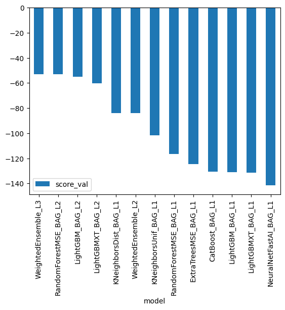

```python
# Output the model's `score_val` in a bar chart to compare performance
predictor.leaderboard(silent=True).plot(kind="bar", x="model", y="score_val")
```

### Create predictions from test dataset

```python
# From the training model we can predict using the test dataset
predictions = predictor.predict(test)
predictions.head()
```

```
0    22.122372
1    41.917908
2    45.763500
3    48.994293
4    51.332268
Name: count, dtype: float32
```

#### NOTE: Kaggle will reject the submission if we don't set everything to be > 0.

```python
# Describe the `predictions` series to see if there are any negative values
predictions.describe()
```

```
count    6493.000000
mean      100.653908
std        89.810127
min         3.099611
25%        20.283205
50%        63.009544
75%       167.569397
max       366.031281
Name: count, dtype: float64
```

```python
# How many negative values do we have?
print("Total prediction:", len(predictions))
print("Total negative value:", (predictions < 0).sum())
print("Total positive value:", (predictions > 0).sum())
```

```
Total prediction: 6493
Total negative value: 0
Total positive value: 6493
```

```python
# Set them to zero
predictions[predictions < 0 ] = 0
# check
print("Total negative value:", (predictions < 0).sum())
```

```
Total negative value: 0
```

### Set predictions to submission dataframe, save, and submit

```python
submission["count"] = predictions
submission.to_csv("submission.csv", index=False)
```

```python
!kaggle competitions submit -c bike-sharing-demand -f submission.csv -m "first raw submission"
```

```
100% 188k/188k [00:00<00:00, 253kB/s]
Successfully submitted to Bike Sharing Demand
```

#### View submission via the command line or in the web browser under the competition's page - `My Submissions`

```python
!kaggle competitions submissions -c bike-sharing-demand | tail -n +1 | head -n 6
```

```
fileName                     date                 description           status    publicScore  privateScore
---------------------------  -------------------  --------------------  --------  -----------  ------------
submission.csv               2023-06-03 11:51:10  first raw submission  complete  1.79786      1.79786
submission_new_features.csv  2023-06-03 09:35:43  new features          complete  0.45403      0.45403
submission.csv               2023-06-03 08:57:53  first raw submission  complete  1.80209      1.80209
```

#### Initial score of `1.79786`

## Step 4: Exploratory Data Analysis and Creating an additional feature

- Any additional feature will do, but a great suggestion would be to separate out the datetime into hour, day, or month parts.

### EDA before new features

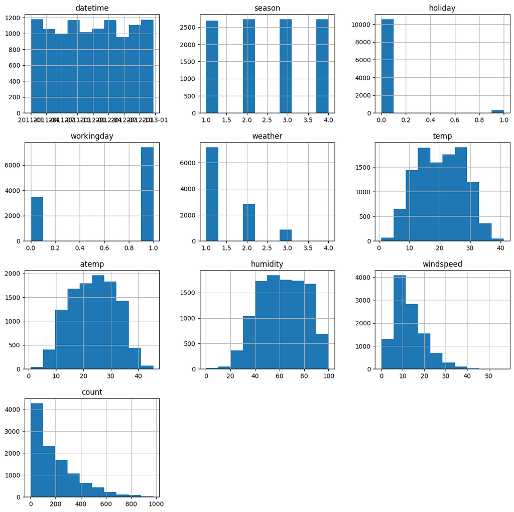

```python
# Create a histogram of all features to show the distribution of each one relative to the data. This is part of the exploritory data analysis
train.hist(figsize=(14,14));
plt.xlabel('Value')
plt.ylabel('Frequency')
plt.show()
```

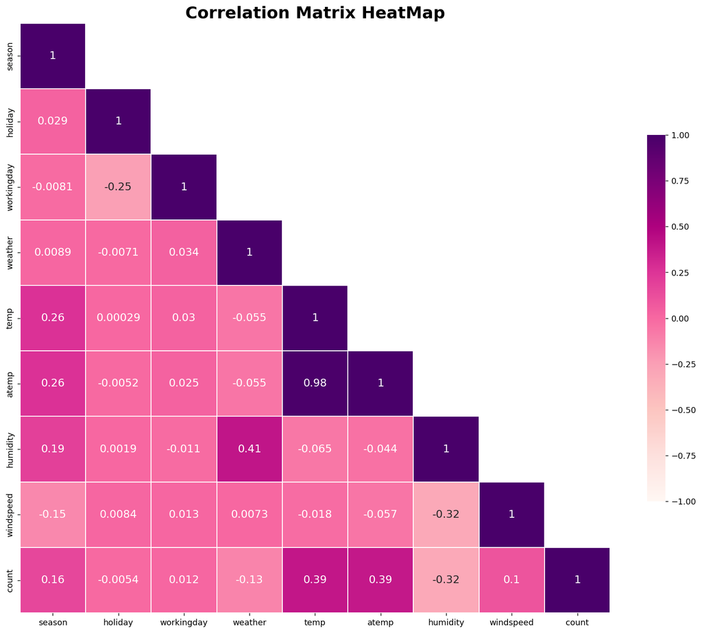

```python
# Using `corr()` method we can identify which variables are strongly correlated with the target variable
cor_matrix = train.corr()
# We can also display the correlation using HeatMap seaborn libraries
plt.figure(figsize = (16,16), dpi = 130)
corr_m = np.array(cor_matrix)
corr_m[np.tril_indices_from(corr_m)] = False
sn.heatmap(cor_matrix, cmap='RdPu', cbar_kws={"shrink": .5}, vmin=-1, vmax=1, center=0,
            square=True, mask=corr_m, annot=True, linewidths=.01, annot_kws={"size":13})
plt.title("Correlation Matrix HeatMap", fontsize=20, fontweight='bold')
```

**Insight**: As we can see from heatmap, two features, atemp and temp, are highly correlated. Thus, we should remove one of them to avoid redundancy. According to literature, 'atemp' (feeling like temperature) is more relevant that 'temp'.

### Creating new features

#### 1. Time based features

Inorder to capture pattern and trends in bike usage over time, we can extract additional information such as the hours of the day, day of the week or months of the year and the year it self from `datetime` feature.

```python
# create a new feature
# We can create four different features from the datetime column for the test and train dataset
new_train = train.copy()
new_test = test.copy()

# Extracting year, month, day, and hour from datetime column
new_train['year'] = new_train.datetime.dt.year
new_train['month'] = new_train.datetime.dt.month
new_train['day_of_week'] = new_train.datetime.dt.dayofweek
new_train['hour'] = new_train.datetime.dt.hour

#Creating a binary feature that indicates whether the given day is weekend(saturday or sunday) day or not
new_train['weekend'] = (new_train['day_of_week'] >=5).astype(int)
# create categorical features that indicate the day of the week which can capture d/f in bike rental demand b/n different weekdays

# for test
# Extracting year, month, day, and hour from datetime column
new_test['year'] = new_test.datetime.dt.year
new_test['month'] = new_test.datetime.dt.month
new_test['day_of_week'] = new_test.datetime.dt.dayofweek
new_test['hour'] = new_test.datetime.dt.hour

#Creating a binary feature that indicates whether the given day is weekend(saturday or sunday) day or not
new_test['weekend'] = (new_test['day_of_week'] >=5).astype(int)
# create categorical features that indicate the day of the week which can capture d/f in bike rental demand b/n different weekdays
new_train.drop(['datetime'], axis =1, inplace =True)
new_test.drop(['datetime'], axis = 1, inplace =True)
# inspect the new dataframe
new_train.head()
```

|  | season | holiday | workingday | weather | temp | atemp | humidity | windspeed | count | year | month | day_of_week | hour | weekend |
| --- | --- | --- | --- | --- | --- | --- | --- | --- | --- | --- | --- | --- | --- | --- |
| 0 | 1 | 0 | 0 | 1 | 9.84 | 14.395 | 81 | 0.0 | 16 | 2011 | 1 | 5 | 0 | 1 |
| 1 | 1 | 0 | 0 | 1 | 9.02 | 13.635 | 80 | 0.0 | 40 | 2011 | 1 | 5 | 1 | 1 |
| 2 | 1 | 0 | 0 | 1 | 9.02 | 13.635 | 80 | 0.0 | 32 | 2011 | 1 | 5 | 2 | 1 |
| 3 | 1 | 0 | 0 | 1 | 9.84 | 14.395 | 75 | 0.0 | 13 | 2011 | 1 | 5 | 3 | 1 |
| 4 | 1 | 0 | 0 | 1 | 9.84 | 14.395 | 75 | 0.0 | 1 | 2011 | 1 | 5 | 4 | 1 |

```python
new_train.info()
```

```
<class 'pandas.core.frame.DataFrame'>
RangeIndex: 10886 entries, 0 to 10885
Data columns (total 14 columns):
 #   Column       Non-Null Count  Dtype
---  ------       --------------  -----
 0   season       10886 non-null  int64
 1   holiday      10886 non-null  int64
 2   workingday   10886 non-null  int64
 3   weather      10886 non-null  int64
 4   temp         10886 non-null  float64
 5   atemp        10886 non-null  float64
 6   humidity     10886 non-null  int64
 7   windspeed    10886 non-null  float64
 8   count        10886 non-null  int64
 9   year         10886 non-null  int64
 10  month        10886 non-null  int64
 11  day_of_week  10886 non-null  int64
 12  hour         10886 non-null  int64
 13  weekend      10886 non-null  int64
dtypes: float64(3), int64(11)
memory usage: 1.2 MB
```

## Make category types for these so models know they are not just numbers

- AutoGluon originally sees these as ints, but in reality they are int representations of a category.
- Setting the dtype to category will classify these as categories in AutoGluon.

```python
# Season and weather are categorical data, so we have to convert these feature from 'int' to category

new_train["season"] = new_train['season'].astype('category')
new_train["weather"] = new_train['weather'].astype('category')
#new_train['day_of_week_name'] = new_train['day_of_week_name'].astype('category')
# For test data
new_test["season"] = new_test["season"].astype('category')
new_test["weather"] = new_test['weather'].astype('category')
#new_test['day_of_week_name'] = new_test['day_of_week_name'].astype('category')
```

```python
# View the data type
new_train.info()
```

```
<class 'pandas.core.frame.DataFrame'>
RangeIndex: 10886 entries, 0 to 10885
Data columns (total 14 columns):
 #   Column       Non-Null Count  Dtype
---  ------       --------------  -----
 0   season       10886 non-null  category
 1   holiday      10886 non-null  int64
 2   workingday   10886 non-null  int64
 3   weather      10886 non-null  category
 4   temp         10886 non-null  float64
 5   atemp        10886 non-null  float64
 6   humidity     10886 non-null  int64
 7   windspeed    10886 non-null  float64
 8   count        10886 non-null  int64
 9   year         10886 non-null  int64
 10  month        10886 non-null  int64
 11  day_of_week  10886 non-null  int64
 12  hour         10886 non-null  int64
 13  weekend      10886 non-null  int64
dtypes: category(2), float64(3), int64(9)
memory usage: 1.0 MB
```

### EDA after adding new features

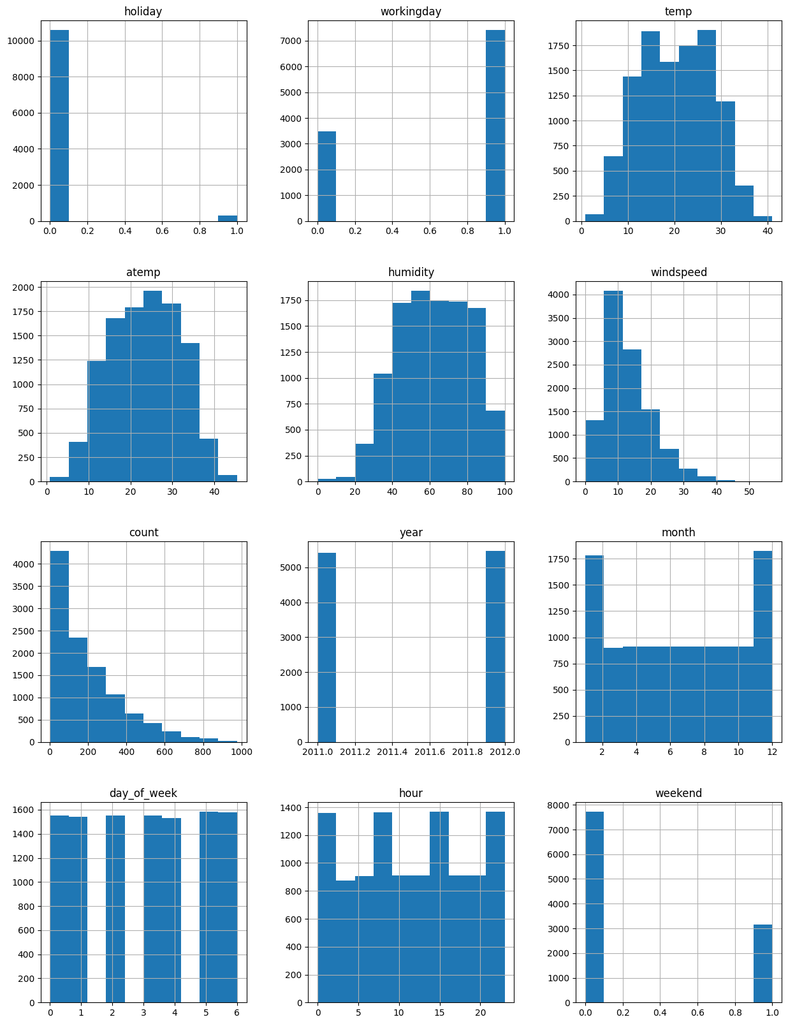

```python
# View histogram of all features again now with the hour feature
new_train.hist(figsize=(15,20));
```

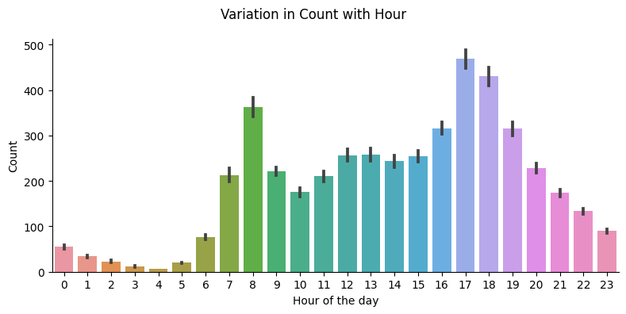

```python
g = sn.catplot(x="hour", y="count", data=new_train, kind='bar', height=4, aspect=2)
g.set_axis_labels('Hour of the day', 'Count')
g.fig.suptitle('Variation in Count with Hour')
plt.tight_layout()
plt.show()
```

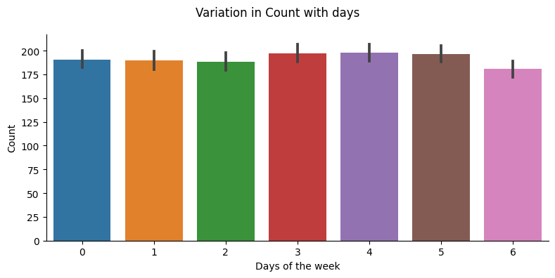

```python
g = sn.catplot(x="day_of_week", y="count", data=new_train, kind='bar', height=4, aspect=2)
g.set_axis_labels('Days of the week', 'Count')
g.fig.suptitle('Variation in Count with days')
plt.tight_layout()
plt.show()
```

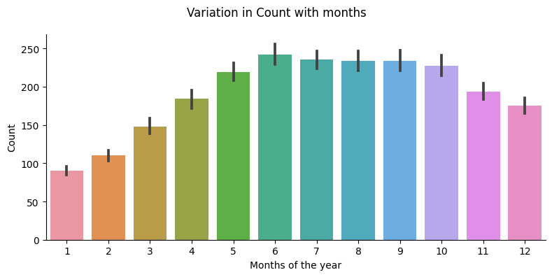

```python
g = sn.catplot(x="month", y="count", data=new_train, kind='bar', height=4, aspect=2)
g.set_axis_labels('Months of the year', 'Count')
g.fig.suptitle('Variation in Count with months')
plt.tight_layout()
plt.show()
```

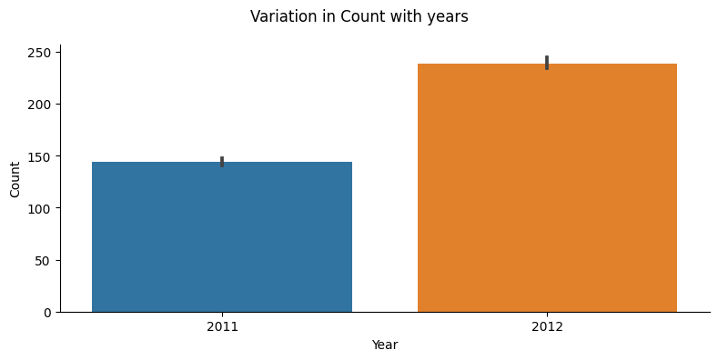

```python
g = sn.catplot(x="year", y="count", data=new_train, kind='bar', height=4, aspect=2)
g.set_axis_labels('Year', 'Count')
g.fig.suptitle('Variation in Count with years')
plt.tight_layout()
plt.show()
```

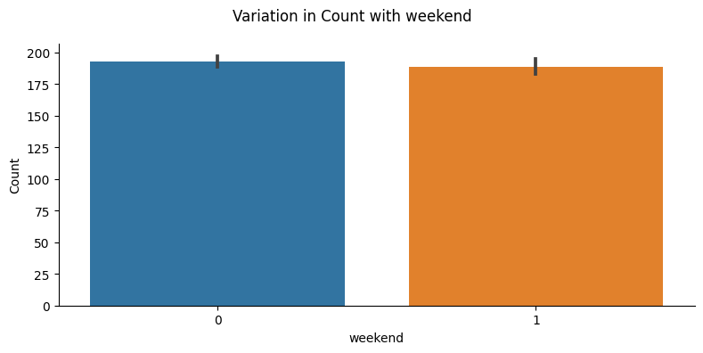

```python
g = sn.catplot(x="weekend", y="count", data=new_train, kind='bar', height=4, aspect=2)
g.set_axis_labels('weekend', 'Count')
g.fig.suptitle('Variation in Count with weekend')
plt.tight_layout()
plt.show()
```

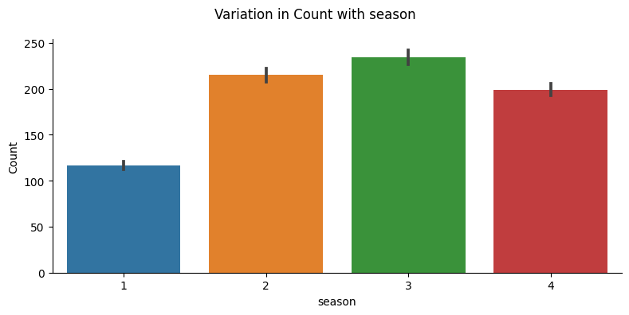

```python
g = sn.catplot(x="season", y="count", data=new_train, kind='bar', height=4, aspect=2)
g.set_axis_labels('season', 'Count')
g.fig.suptitle('Variation in Count with season')
plt.tight_layout()
plt.show()
```

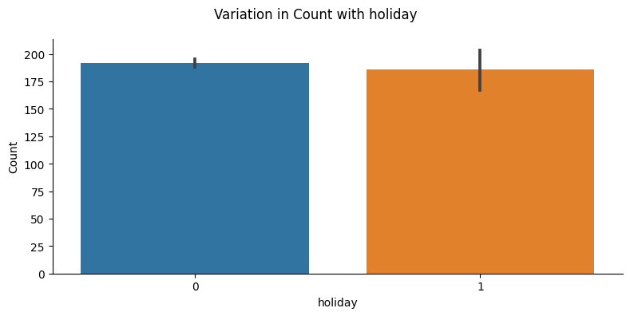

```python
g = sn.catplot(x="holiday", y="count", data=new_train, kind='bar', height=4, aspect=2)
g.set_axis_labels('holiday', 'Count')
g.fig.suptitle('Variation in Count with holiday')
plt.tight_layout()
plt.show()
```

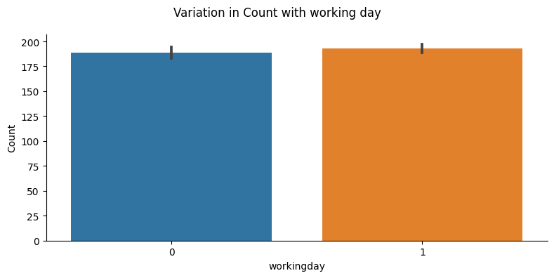

```python
g = sn.catplot(x="workingday", y="count", data=new_train, kind='bar', height=4, aspect=2)
g.set_axis_labels('workingday', 'Count')
g.fig.suptitle('Variation in Count with working day')
plt.tight_layout()
plt.show()
```

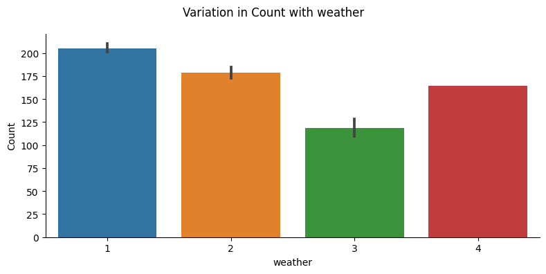

```python
g = sn.catplot(x="weather", y="count", data=new_train, kind='bar', height=4, aspect=2)
g.set_axis_labels('weather', 'Count')
g.fig.suptitle('Variation in Count with weather')
plt.tight_layout()
plt.show()
```

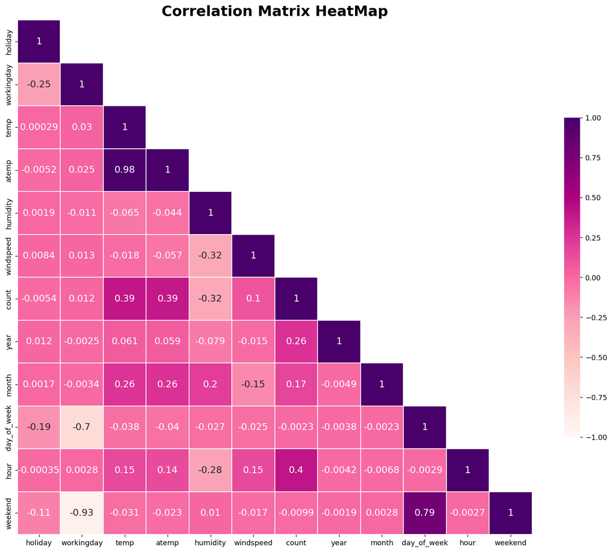

```python
# Using `corr()` method we can identify which variables are strongly correlated with the target variable
cor_matrix = new_train.corr()
# We can also display the correlation using HeatMap seaborn libraries
plt.figure(figsize = (16,16), dpi = 130)
corr_m = np.array(cor_matrix)
corr_m[np.tril_indices_from(corr_m)] = False
sn.heatmap(cor_matrix, cmap='RdPu', cbar_kws={"shrink": .5}, vmin=-1, vmax=1, center=0,
            square=True, mask=corr_m, annot=True, linewidths=.01, annot_kws={"size":13})
plt.title("Correlation Matrix HeatMap", fontsize=20, fontweight='bold')
```

```python
#Remove highly correlated dataset from both taining and testing dataset
new_train.drop(["temp","weekend"], axis=1, inplace=True)
new_test.drop(["temp","weekend"], axis=1, inplace=True)
```

```python
new_train.head()
```

|  | season | holiday | workingday | weather | atemp | humidity | windspeed | count | year | month | day_of_week | hour |
| --- | --- | --- | --- | --- | --- | --- | --- | --- | --- | --- | --- | --- |
| 0 | 1 | 0 | 0 | 1 | 14.395 | 81 | 0.0 | 16 | 2011 | 1 | 5 | 0 |
| 1 | 1 | 0 | 0 | 1 | 13.635 | 80 | 0.0 | 40 | 2011 | 1 | 5 | 1 |
| 2 | 1 | 0 | 0 | 1 | 13.635 | 80 | 0.0 | 32 | 2011 | 1 | 5 | 2 |
| 3 | 1 | 0 | 0 | 1 | 14.395 | 75 | 0.0 | 13 | 2011 | 1 | 5 | 3 |
| 4 | 1 | 0 | 0 | 1 | 14.395 | 75 | 0.0 | 1 | 2011 | 1 | 5 | 4 |

```python
new_test.head()
```

|  | season | holiday | workingday | weather | atemp | humidity | windspeed | year | month | day_of_week | hour |
| --- | --- | --- | --- | --- | --- | --- | --- | --- | --- | --- | --- |
| 0 | 1 | 0 | 1 | 1 | 11.365 | 56 | 26.0027 | 2011 | 1 | 3 | 0 |
| 1 | 1 | 0 | 1 | 1 | 13.635 | 56 | 0.0000 | 2011 | 1 | 3 | 1 |
| 2 | 1 | 0 | 1 | 1 | 13.635 | 56 | 0.0000 | 2011 | 1 | 3 | 2 |
| 3 | 1 | 0 | 1 | 1 | 12.880 | 56 | 11.0014 | 2011 | 1 | 3 | 3 |
| 4 | 1 | 0 | 1 | 1 | 12.880 | 56 | 11.0014 | 2011 | 1 | 3 | 4 |

## Step 5: Rerun the model with the same settings as before, just with more features

```python
# training a model using AutoGluon's Tabular prediction with more features
predictor_new_features = TabularPredictor(
    label = "count",
    problem_type="regression",
    eval_metric="rmse").fit(train_data = new_train, time_limit = 600, presets = "best_quality")
```

```
No path specified. Models will be saved in: "AutogluonModels/ag-20230603_115129/"
Presets specified: ['best_quality']
Stack configuration (auto_stack=True): num_stack_levels=1, num_bag_folds=8, num_bag_sets=20
Beginning AutoGluon training ... Time limit = 600s
AutoGluon will save models to "AutogluonModels/ag-20230603_115129/"
AutoGluon Version:  0.7.0
Python Version:     3.10.11
Operating System:   Linux
Platform Machine:   x86_64
Platform Version:   #1 SMP Sat Apr 29 09:15:28 UTC 2023
Train Data Rows:    10886
Train Data Columns: 11
Label Column: count
Preprocessing data ...
Using Feature Generators to preprocess the data ...
Fitting AutoMLPipelineFeatureGenerator...
	Available Memory:                    11754.85 MB
	Train Data (Original)  Memory Usage: 0.81 MB (0.0% of available memory)
	Inferring data type of each feature based on column values. Set feature_metadata_in to manually specify special dtypes of the features.
	Stage 1 Generators:
		Fitting AsTypeFeatureGenerator...
			Note: Converting 3 features to boolean dtype as they only contain 2 unique values.
	Stage 2 Generators:
		Fitting FillNaFeatureGenerator...
	Stage 3 Generators:
		Fitting IdentityFeatureGenerator...
		Fitting CategoryFeatureGenerator...
			Fitting CategoryMemoryMinimizeFeatureGenerator...
	Stage 4 Generators:
		Fitting DropUniqueFeatureGenerator...
	Types of features in original data (raw dtype, special dtypes):
		('category', []) : 2 | ['season', 'weather']
		('float', [])    : 2 | ['atemp', 'windspeed']
		('int', [])      : 7 | ['holiday', 'workingday', 'humidity', 'year', 'month', ...]
	Types of features in processed data (raw dtype, special dtypes):
		('category', [])  : 2 | ['season', 'weather']
		('float', [])     : 2 | ['atemp', 'windspeed']
		('int', [])       : 4 | ['humidity', 'month', 'day_of_week', 'hour']
		('int', ['bool']) : 3 | ['holiday', 'workingday', 'year']
	0.1s = Fit runtime
```

[output cut: 61 more lines]

```
	-34.9532	 = Validation score   (-root_mean_squared_error)
	44.02s	 = Training   runtime
	0.68s	 = Validation runtime
Fitting model: CatBoost_BAG_L2 ... Training model for up to 34.89s of the 34.86s of remaining time.
	Fitting 8 child models (S1F1 - S1F8) | Fitting with ParallelLocalFoldFittingStrategy
	-34.2994	 = Validation score   (-root_mean_squared_error)
	47.26s	 = Training   runtime
	0.14s	 = Validation runtime
Completed 1/20 k-fold bagging repeats ...
Fitting model: WeightedEnsemble_L3 ... Training model for up to 360.0s of the -16.11s of remaining time.
	-34.1602	 = Validation score   (-root_mean_squared_error)
	0.3s	 = Training   runtime
	0.0s	 = Validation runtime
AutoGluon training complete, total runtime = 616.52s ... Best model: "WeightedEnsemble_L3"
TabularPredictor saved. To load, use: predictor = TabularPredictor.load("AutogluonModels/ag-20230603_115129/")
```

```python
predictor_new_features.fit_summary()
```

```
*** Summary of fit() ***
Estimated performance of each model:
                     model   score_val  pred_time_val    fit_time  pred_time_val_marginal  fit_time_marginal  stack_level  can_infer  fit_order
0      WeightedEnsemble_L3  -34.160193      26.742727  546.982573                0.000840           0.300499            3       True         14
1      WeightedEnsemble_L2  -34.224547      23.753172  375.457592                0.001122           0.676243            2       True          9
2          CatBoost_BAG_L2  -34.299411      24.761175  466.960114                0.139664          47.261172            2       True         13
3          LightGBM_BAG_L2  -34.835420      25.140070  450.086541                0.518559          30.387599            2       True         11
4   RandomForestMSE_BAG_L2  -34.953159      25.305498  463.719940                0.683987          44.020998            2       True         12
5        LightGBMXT_BAG_L2  -35.100106      25.918237  455.399904                1.296726          35.700961            2       True         10
6          LightGBM_BAG_L1  -35.896563       4.283199   53.390105                4.283199          53.390105            1       True          4
7          CatBoost_BAG_L1  -36.251646       0.520814  182.509605                0.520814         182.509605            1       True          6
8        LightGBMXT_BAG_L1  -36.486717      17.604650  114.155684               17.604650         114.155684            1       True          3
9     ExtraTreesMSE_BAG_L1  -38.738106       0.588643    8.718709                0.588643           8.718709            1       True          7
10  RandomForestMSE_BAG_L1  -39.643244       0.754744   16.007245                0.754744          16.007245            1       True          5
11   KNeighborsDist_BAG_L1 -111.426980       0.114670    0.026835                0.114670           0.026835            1       True          2
12   KNeighborsUnif_BAG_L1 -114.798749       0.161065    0.047195                0.161065           0.047195            1       True          1
13  NeuralNetFastAI_BAG_L1 -127.544970       0.593726   44.843563                0.593726          44.843563            1       True          8
Number of models trained: 14
Types of models trained:
{'StackerEnsembleModel_RF', 'StackerEnsembleModel_CatBoost', 'StackerEnsembleModel_XT', 'StackerEnsembleModel_KNN', 'StackerEnsembleModel_LGB', 'StackerEnsembleModel_NNFastAiTabular', 'WeightedEnsembleModel'}
Bagging used: True  (with 8 folds)
Multi-layer stack-ensembling used: True  (with 3 levels)
Feature Metadata (Processed):
(raw dtype, special dtypes):
('category', [])  : 2 | ['season', 'weather']
('float', [])     : 2 | ['atemp', 'windspeed']
('int', [])       : 4 | ['humidity', 'month', 'day_of_week', 'hour']
('int', ['bool']) : 3 | ['holiday', 'workingday', 'year']
*** End of fit() summary ***
```

[output not shown]

[output cut: 126 more lines]

```
     fit_order
 0          14
 1           9
 2          13
 3          11
 4          12
 5          10
 6           4
 7           6
 8           3
 9           7
 10          5
 11          2
 12          1
 13          8  }
```

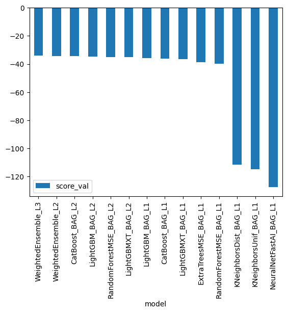

```python
# Output the model's `score_val` in a bar chart to compare performance
predictor_new_features.leaderboard(silent=True).plot(kind="bar", x="model", y="score_val")
```

```python
# now let us predict the test data
predicted_new_features = predictor_new_features.predict(new_test)
predicted_new_features.head()
```

```
0    12.412106
1     6.234686
2     4.731555
3     4.173356
4     4.231236
Name: count, dtype: float32
```

```python
# Remember to set all negative values to zero
print("Total prediction:", len(predicted_new_features))
print("Total negative value:", (predicted_new_features < 0).sum())
print("Total positive value:", (predicted_new_features > 0).sum())
# Set them to zero
predicted_new_features[predicted_new_features < 0 ] = 0
# check
print("Total negative value:", (predicted_new_features < 0).sum())
```

```
Total prediction: 6493
Total negative value: 0
Total positive value: 6493
Total negative value: 0
```

```python
submission_new_features = pd.read_csv('sampleSubmission.csv', parse_dates=['datetime'])
submission_new_features.head()
```

|  | datetime | count |
| --- | --- | --- |
| 0 | 2011-01-20 00:00:00 | 0 |
| 1 | 2011-01-20 01:00:00 | 0 |
| 2 | 2011-01-20 02:00:00 | 0 |
| 3 | 2011-01-20 03:00:00 | 0 |
| 4 | 2011-01-20 04:00:00 | 0 |

```python
# Same submitting predictions
submission_new_features["count"] = predicted_new_features
submission_new_features.to_csv("submission_new_features.csv", index=False)
submission_new_features.head()
```

|  | datetime | count |
| --- | --- | --- |
| 0 | 2011-01-20 00:00:00 | 12.412106 |
| 1 | 2011-01-20 01:00:00 | 6.234686 |
| 2 | 2011-01-20 02:00:00 | 4.731555 |
| 3 | 2011-01-20 03:00:00 | 4.173356 |
| 4 | 2011-01-20 04:00:00 | 4.231236 |

```python
!kaggle competitions submit -c bike-sharing-demand -f submission_new_features.csv -m "new features"
```

```
100% 188k/188k [00:00<00:00, 224kB/s]
Successfully submitted to Bike Sharing Demand
```

```python
!kaggle competitions submissions -c bike-sharing-demand | tail -n +1 | head -n 6
```

```
fileName                     date                 description           status    publicScore  privateScore
---------------------------  -------------------  --------------------  --------  -----------  ------------
submission_new_features.csv  2023-06-03 12:02:52  new features          complete  0.45744      0.45744
submission.csv               2023-06-03 11:51:10  first raw submission  complete  1.79786      1.79786
submission_new_features.csv  2023-06-03 09:35:43  new features          complete  0.45403      0.45403
submission.csv               2023-06-03 08:57:53  first raw submission  complete  1.80209      1.80209
```

#### New Score of `0.45744`

## Step 6: Hyper parameter optimization

- There are many options for hyper parameter optimization.
- Options are to change the AutoGluon higher level parameters or the individual model hyperparameters.
- The hyperparameters of the models themselves that are in AutoGluon. Those need the `hyperparameter` and `hyperparameter_tune_kwargs` arguments.

```python
import autogluon.core as ag
# Define hyperparameters for NN_TORCH GBM, CAT, XGB, and FASTAI models
hyperparameters = {
    'NN_TORCH': {
        'num_epochs': 10,
        'learning_rate': ag.space.Real(1e-4, 1e-1, default=5e-4, log=True),
    },
    'GBM': [
        {
            'num_boost_round': 100,
            'num_leaves': ag.space.Int(lower=26, upper=66, default=36),
        },
    ],
    'CAT': {'learning_rate': ag.space.Real(1e-4, 1e-2, default=5e-4, log=True),
            'l2_leaf_reg': ag.space.Real(1.0, 5.0, default=3)},

    'XGB': {'eta': ag.space.Real(0.01, 0.3, default=0.1, log=True)},
    'FASTAI': {
        'learning_rate': ag.space.Real(1e-4, 1e-2, default=5e-4, log=True),
        'pretrained': ag.space.Categorical(True, False),
    },
    'RF': {},
    'XT': {},
    'KNN':{},
}

predictor_new_hpo = TabularPredictor(label='count', eval_metric='rmse').fit(
    train_data=new_train,auto_stack = True, time_limit = 900,
    presets='best_quality',hyperparameters=hyperparameters, hyperparameter_tune_kwargs='auto')
```

```
Fitted model: NeuralNetTorch_BAG_L2/84ab324e ...
	-36.9832	 = Validation score   (-root_mean_squared_error)
	50.86s	 = Training   runtime
	0.0s	 = Validation runtime
Completed 1/20 k-fold bagging repeats ...
Fitting model: WeightedEnsemble_L3 ... Training model for up to 360.0s of the 167.08s of remaining time.
	-35.6331	 = Validation score   (-root_mean_squared_error)
	1.08s	 = Training   runtime
	0.0s	 = Validation runtime
AutoGluon training complete, total runtime = 734.13s ... Best model: "WeightedEnsemble_L3"
TabularPredictor saved. To load, use: predictor = TabularPredictor.load("AutogluonModels/ag-20230605_112334/")
```

```python
# now let us predict the test data
predicted_new_hpo = predictor_new_hpo.predict(new_test)
predicted_new_hpo.head()
```

```
0    11.532742
1     5.022551
2     3.271088
3     2.980826
4     2.877086
Name: count, dtype: float32
```

[output not shown]

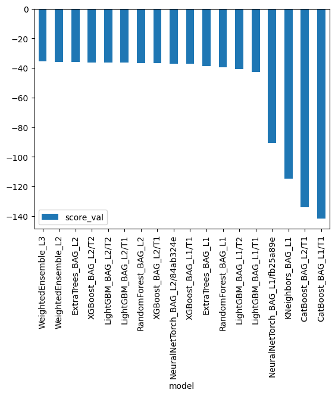

```python
predictor_new_hpo.fit_summary()
# Output the model's `score_val` in a bar chart to compare performance
predictor_new_hpo.leaderboard(silent=True).plot(kind="bar", x="model", y="score_val")
plt.show()
```

```python
# Remember to set all negative values to zero
print("Total prediction:", len(predicted_new_hpo))
print("Total negative value:", (predicted_new_hpo < 0).sum())
print("Total positive value:", (predicted_new_hpo > 0).sum())
# Set them to zero
predicted_new_hpo[predicted_new_hpo < 0 ] = 0
# check
print("Total negative value:", (predicted_new_hpo < 0).sum())
```

```
Total prediction: 6493
Total negative value: 0
Total positive value: 6493
Total negative value: 0
```

```python
submission_new_hpo = pd.read_csv('sampleSubmission.csv', parse_dates=['datetime'])
submission_new_hpo.head()
```

|  | datetime | count |
| --- | --- | --- |
| 0 | 2011-01-20 00:00:00 | 0 |
| 1 | 2011-01-20 01:00:00 | 0 |
| 2 | 2011-01-20 02:00:00 | 0 |
| 3 | 2011-01-20 03:00:00 | 0 |
| 4 | 2011-01-20 04:00:00 | 0 |

```python
# Same submitting predictions
submission_new_hpo["count"] = predicted_new_hpo
submission_new_hpo.to_csv("submission_new_hpo.csv", index=False)
submission_new_hpo.head()
```

|  | datetime | count |
| --- | --- | --- |
| 0 | 2011-01-20 00:00:00 | 11.532742 |
| 1 | 2011-01-20 01:00:00 | 5.022551 |
| 2 | 2011-01-20 02:00:00 | 3.271088 |
| 3 | 2011-01-20 03:00:00 | 2.980826 |
| 4 | 2011-01-20 04:00:00 | 2.877086 |

```python
!kaggle competitions submit -c bike-sharing-demand -f submission_new_hpo.csv -m "new features with hyperparameters"
```

```python
!kaggle competitions submissions -c bike-sharing-demand | tail -n +1 | head -n 6
```

[output not shown]